# Google Analytics_R for Data Visualization

Jiuru Lyu

Jul 21, 2022

```r
library("ggplot2")
library("palmerpenguins")
```

# ggplot2 First Impression

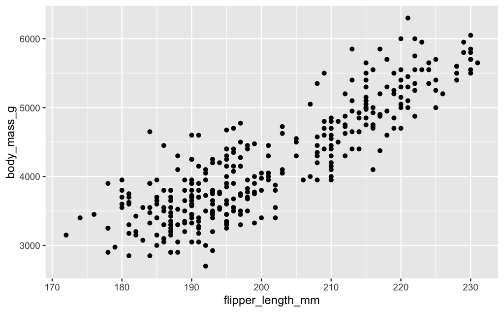

```r
ggplot(data=penguins) +
  geom_point(mapping=aes(x=flipper_length_mm,y=body_mass_g))
```

1. `ggplot(data=data_name)` tells what data frame ggplot2 should work with.
2. The plus sign (`+`) adds a layer to the plot. ggplot2 creates plots using multiple layers.
3. `geom_point` tells ggplot2 to use points to represent data points.
4. `mapping=aes()` tells ggplot2 the aesthetic.

**`ggplot(data=<DATA>)+<GEOM_FUNCTION>(mapping=aes(<AESTHETIC MAPPINGS>))`**

*Example:*

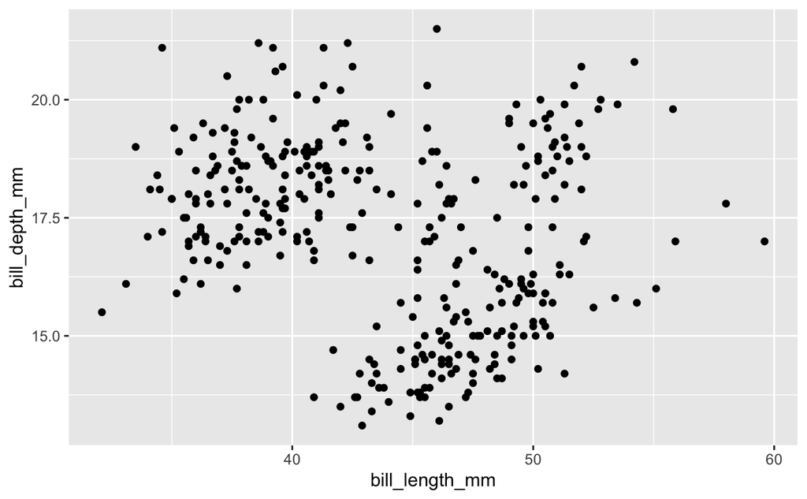

```r
ggplot(data=penguins) +
  geom_point(mapping=aes(x=bill_length_mm,y=bill_depth_mm))
```

# Explore Aesthetics in Analysis

Adding a new aesthetic to our previous code:

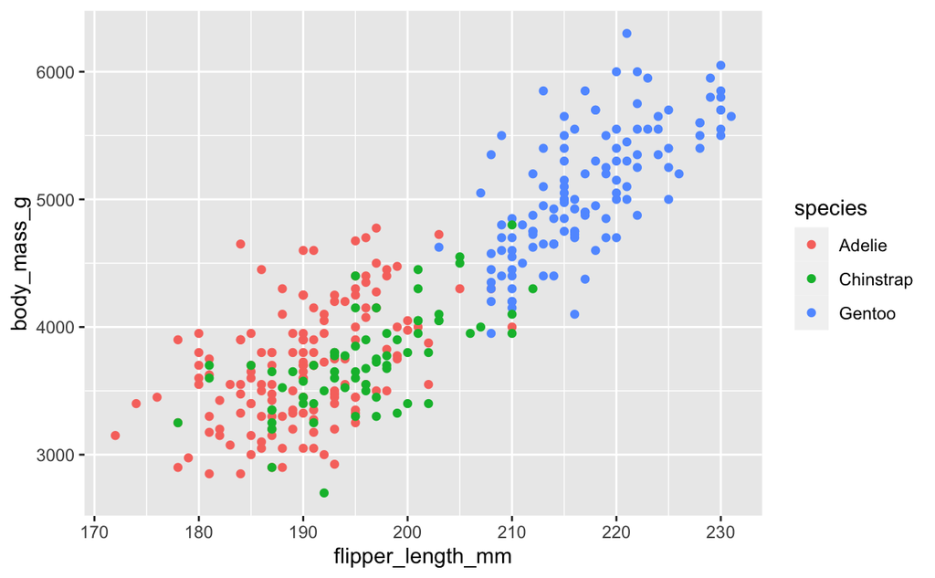

```r
ggplot(data=penguins) +
  geom_point(mapping=aes(x=flipper_length_mm,y=body_mass_g,color=species))
```

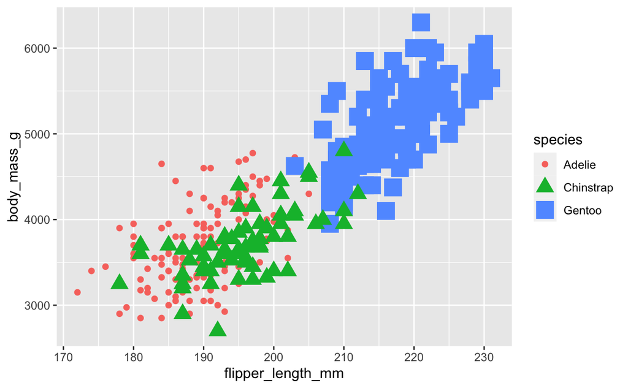

```r
ggplot(data=penguins) +
  geom_point(mapping=aes(x=flipper_length_mm,y=body_mass_g,color=species,shape=species,size=species))
```

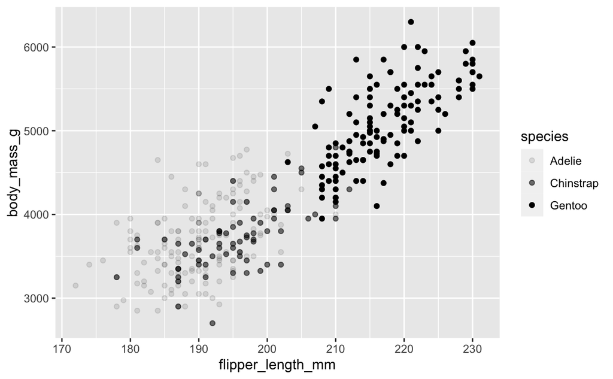

```r
ggplot(data=penguins) +
  geom_point(mapping=aes(x=flipper_length_mm,y=body_mass_g,alpha=species))
```

You can also add code outside the aes function. In this case, you are not mapping to the variable, but you are changing the overall plot.

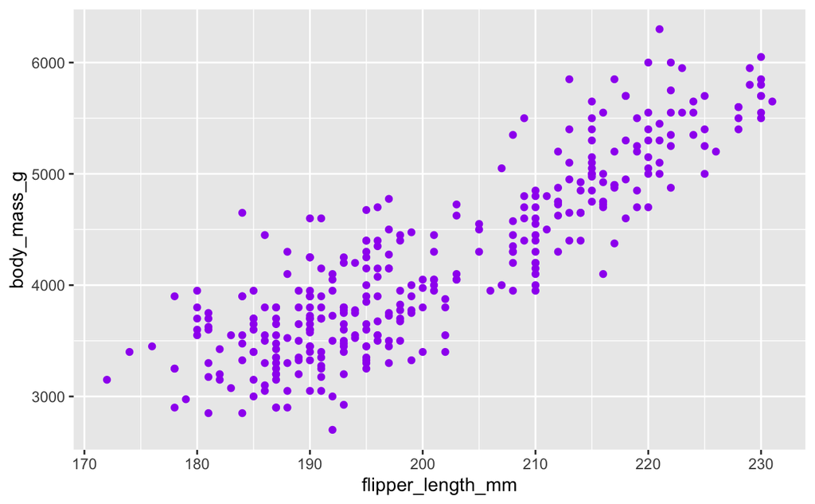

```r
ggplot(data=penguins) +
  geom_point(mapping=aes(x=flipper_length_mm,y=body_mass_g),color="purple")
```

## Different Types of Geom

1. geom_point: scatter plot
2. geom_bar: bar charts
3. geom_line
4. geom_smooth: a smooth line with the existing data points
5. geom_jitter: when the data is hard to recognize, use it for better vizulization

```
Warning: Removed 2 rows containing non-finite values (stat_smooth).
Warning: Removed 2 rows containing missing values (geom_point).
```

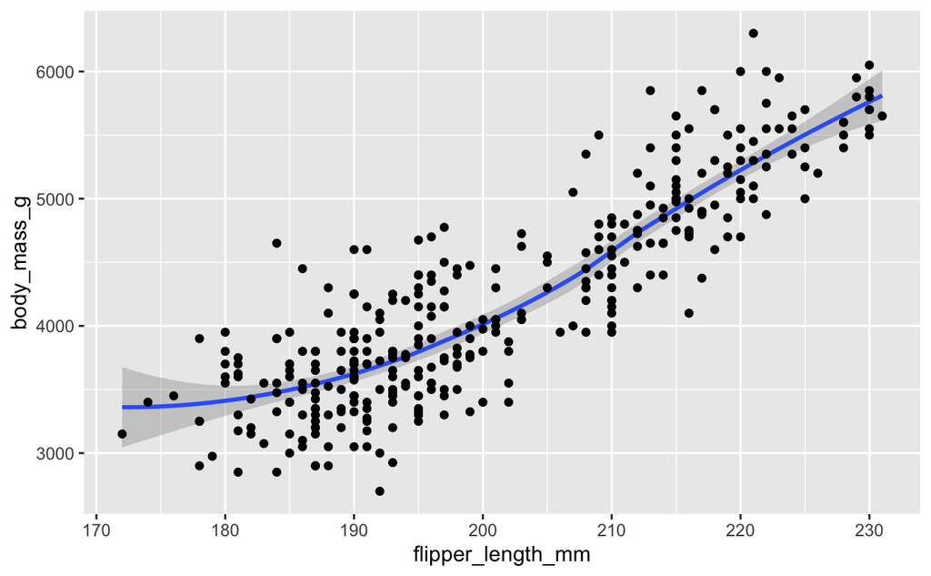

```r
ggplot(data=penguins) +
  geom_smooth(mapping=aes(x=flipper_length_mm,y=body_mass_g)) +
  geom_point(mapping=aes(x=flipper_length_mm,y=body_mass_g))
```

```
Warning: Removed 2 rows containing non-finite values (stat_smooth).
```

[figure not shown]

```r
ggplot(data=penguins) +
  geom_smooth(mapping=aes(x=flipper_length_mm,y=body_mass_g,linetype=species))
```

```
Warning: Removed 2 rows containing non-finite values (stat_smooth).
```

[figure not shown]

```r
ggplot(data=penguins) +
  geom_smooth(mapping=aes(x=flipper_length_mm,y=body_mass_g,linetype=species))
```

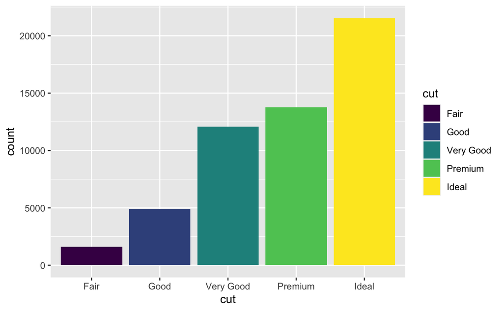

```r
ggplot(data=diamonds) +
  geom_bar(mapping=aes(x=cut,fill=cut))
```

## Aesthetics and Facets

1. facet_wrap: facet the plot with a single variable
2. facet_grid: facet the plot with two variables

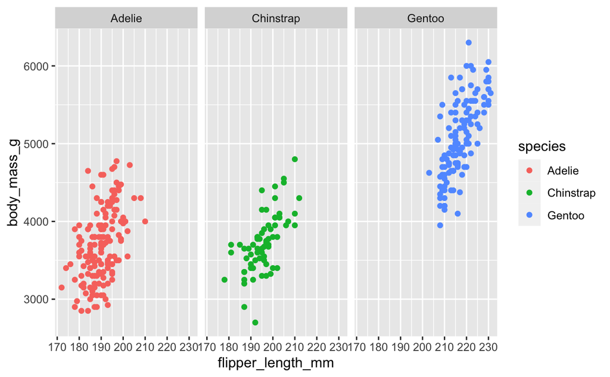

```r
ggplot(data=penguins) +
  geom_point(mapping=aes(x=flipper_length_mm,y=body_mass_g,color=species)) +
  facet_wrap(~species)
```

```r
ggplot(data=diamonds) +
  geom_bar(mapping=aes(x=color,fill=cut)) +
  facet_wrap(~cut)
```

[output not shown]

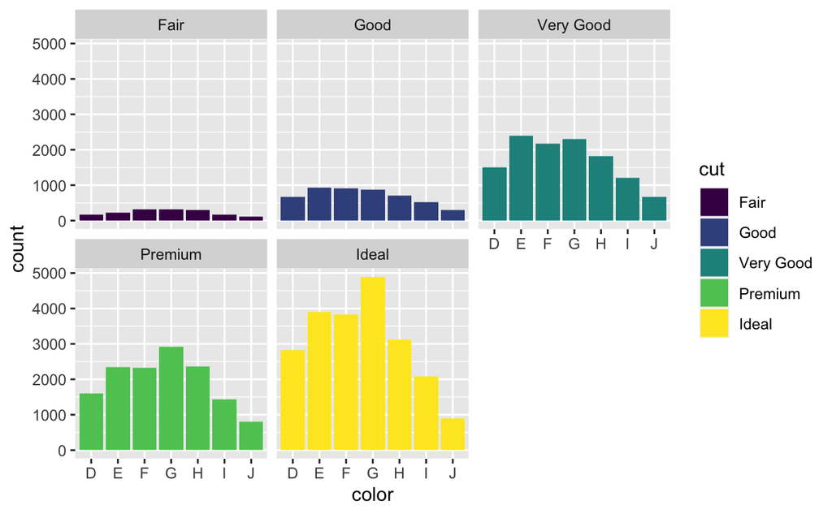

```r
ggplot(data=diamonds) +
  geom_bar(mapping=aes(x=color,fill=cut)) +
  facet_wrap(~cut)
```

# Annotation on the Plot

Adding titles, subtitles, and captions to the plot:

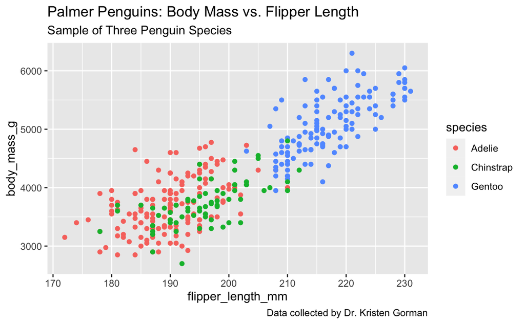

```r
ggplot(data=penguins) +
  geom_point(mapping=aes(x=flipper_length_mm,y=body_mass_g,color=species)) +
  labs(title="Palmer Penguins: Body Mass vs. Flipper Length",subtitle="Sample of Three Penguin Species",caption="Data collected by Dr. Kristen Gorman")
```

Adding annotation to the plot:

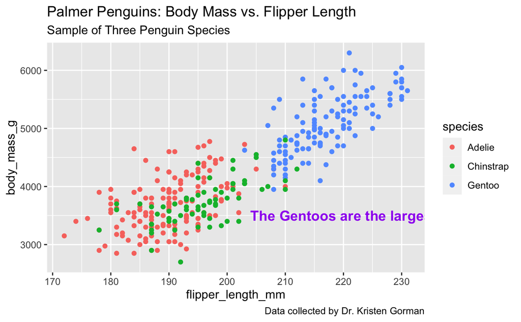

```r
ggplot(data=penguins) +
  geom_point(mapping=aes(x=flipper_length_mm,y=body_mass_g,color=species)) +
  labs(title="Palmer Penguins: Body Mass vs. Flipper Length",subtitle="Sample of Three Penguin Species",caption="Data collected by Dr. Kristen Gorman") +
  annotate("text",x=220,y=3500,label="The Gentoos are the largest",color="purple",fontface="bold",size=4.5)
```

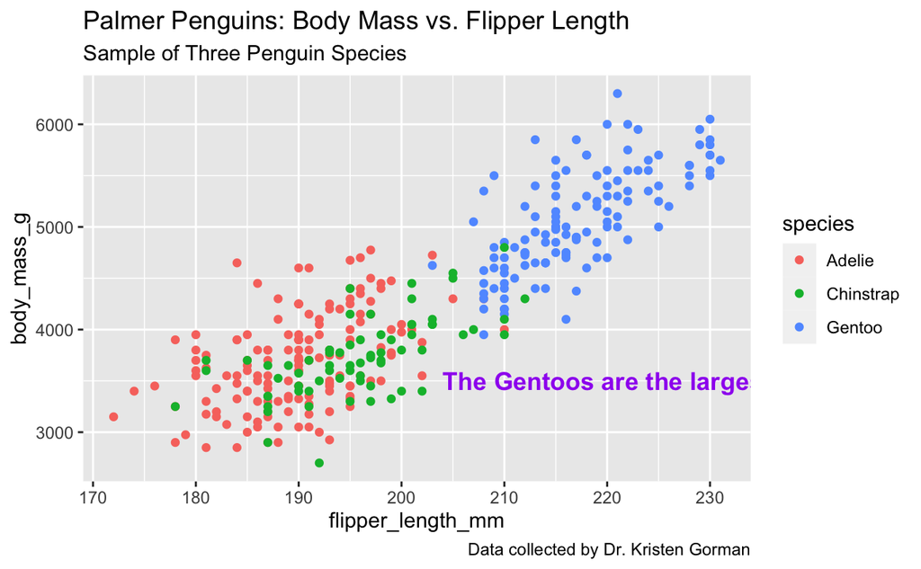

```r
ggplot(data=penguins) +
  geom_point(mapping=aes(x=flipper_length_mm,y=body_mass_g,color=species)) +
  labs(title="Palmer Penguins: Body Mass vs. Flipper Length",subtitle="Sample of Three Penguin Species",caption="Data collected by Dr. Kristen Gorman") +
  annotate("text",x=220,y=3500,label="The Gentoos are the largest",color="purple",fontface="bold",size=4.5)
```

# Save the Plots

Use ggsave(“name”) to save plots.